# Computing distance-regular graph and association scheme parameters in SageMath with [`sage-drg`](https://github.com/jaanos/sage-drg)

### Janoš Vidali

#### University of Ljubljana

[figure not shown]

[Live slides](https://mybinder.org/v2/gh/jaanos/sage-drg/master?filepath=jupyter/2019-07-04-fpsac/FPSAC-sage-drg.ipynb) on [Binder](https://mybinder.org)

https://github.com/jaanos/sage-drg

## Association schemes

- **Association schemes** were defined by *Bose* and *Shimamoto* in *1952* as a theory underlying **experimental design**.
- They provide a unified approach to many topics, such as
  - *combinatorial designs*,
  - *coding theory*,
  - generalizing *groups*, and
  - *strongly regular* and *distance-regular graphs*.

## Examples

- *Hamming schemes*: **$X = \mathbb{Z}_n^d$**, **$x \ R_i \ y \Leftrightarrow \operatorname{weight}(x-y) = i$**
- *Johnson schemes*: **$X = \{S \subseteq \mathbb{Z}_n \;|\; |S| = d\}$** ($2d \le n$), **$x \ R_i \ y \Leftrightarrow |x \cap y| = d-i$**

[figure not shown]

## Definition

- Let **$X$** be a set of *vertices* and **$\mathcal{R} = \{R_0 = \operatorname{id}_X, R_1, \dots, R_D\}$** a set of *symmetric relations* partitioning *$X^2$*.
- **$(X, \mathcal{R})$** is said to be a **$D$-class association scheme** if there exist numbers **$p^h_{ij}$** ($0 \le h, i, j \le D$) such that, for any *$x, y \in X$*, **$$ x \ R_h \ y \Rightarrow |\{z \in X \;|\; x \ R_i \ z \ R_j \ y\}| = p^h_{ij} $$**
- We call the numbers **$p^h_{ij}$** ($0 \le h, i, j \le D$) **intersection numbers**.

## Main problem

- Does an association scheme with given parameters exist?
  - If so, is it unique?
  - Can we determine all such schemes?
- Lists of feasible parameter sets have been compiled for [**strongly regular**](https://www.win.tue.nl/~aeb/graphs/srg/srgtab.html) and [**distance-regular graphs**](https://www.win.tue.nl/~aeb/drg/drgtables.html).
- Recently, lists have also been compiled for some [**$Q$-polynomial association schemes**](http://www.uwyo.edu/jwilliford/).
- Computer software allows us to *efficiently* compute parameters and check for *existence conditions*, and also to obtain new information which would be helpful in the construction of new examples.

## Bose-Mesner algebra

- Let **$A_i$** be the *binary matrix* corresponding to the relation *$R_i$* ($0 \le i \le D$).
- The vector space **$\mathcal{M}$** over *$\mathbb{R}$* spanned by *$A_i$* ($0 \le i \le D$) is called the **Bose-Mesner algebra**.
- *$\mathcal{M}$* has a second basis $\{E_0, E_1, \dots, E_D\}$ consisting of *projectors* to the *common eigenspaces* of *$A_i$* ($0 \le i \le D$).
- There are nonnegative constants **$q^h_{ij}$**, called **Krein parameters**, such that **$$ E_i \circ E_j = {1 \over |X|} \sum_{h=0}^d q^h_{ij} E_h , $$** where **$\circ$** is the *entrywise matrix product*.

## Parameter computation: general association schemes

```python
import drg
p = [[[1, 0, 0, 0], [0, 6, 0, 0], [0, 0, 3, 0], [0, 0, 0, 6]],
     [[0, 1, 0, 0], [1, 2, 1, 2], [0, 1, 0, 2], [0, 2, 2, 2]],
     [[0, 0, 1, 0], [0, 2, 0, 4], [1, 0, 2, 0], [0, 4, 0, 2]],
     [[0, 0, 0, 1], [0, 2, 2, 2], [0, 2, 0, 1], [1, 2, 1, 2]]]
scheme = drg.ASParameters(p)
scheme.kreinParameters()
```

```
0: [1 0 0 0]
   [0 6 0 0]
   [0 0 3 0]
   [0 0 0 6]

1: [0 1 0 0]
   [1 2 1 2]
   [0 1 0 2]
   [0 2 2 2]

2: [0 0 1 0]
   [0 2 0 4]
   [1 0 2 0]
   [0 4 0 2]

3: [0 0 0 1]
   [0 2 2 2]
   [0 2 0 1]
   [1 2 1 2]
```

## Metric and cometric schemes

- If **$p^h_{ij} \ne 0$** (resp. **$q^h_{ij} \ne 0$**) implies **$|i-j| \le h \le i+j$**, then the association scheme is said to be **metric** (resp. **cometric**).
- The *parameters* of a *metric* association scheme can be determined from the **intersection array** *$$ \{b_0, b_1, \dots, b_{D-1}; c_1, c_2, \dots, c_D\} \quad (b_i = p^i_{1,i+1}, c_i = p^i_{1,i-1}). $$*
- The *parameters* of a *cometric* association scheme can be determined from the **Krein array** *$$ \{b^*_0, b^*_1, \dots, b^*_{D-1}; c^*_1, c^*_2, \dots, c^*_D\} \quad (b^*_i = q^i_{1,i+1}, c^*_i = q^i_{1,i-1}). $$*
- *Metric* association schemes correspond to *distance-regular graphs*.

## Parameter computation: metric and cometric schemes

```python
from drg import DRGParameters
syl = DRGParameters([5, 4, 2], [1, 1, 4])
syl
```

```
Parameters of a distance-regular graph with intersection array {5, 4, 2; 1, 1, 4}
```

```python
syl.order()
```

```
36
```

```python
from drg import QPolyParameters
q225 = QPolyParameters([24, 20, 36/11], [1, 30/11, 24])
q225
```

```
Parameters of a Q-polynomial association scheme with Krein array {24, 20, 36/11; 1, 30/11, 24}
```

```python
q225.order()
```

```
225
```

```python
syl.pTable()
```

```
0: [ 1  0  0  0]
   [ 0  5  0  0]
   [ 0  0 20  0]
   [ 0  0  0 10]

1: [0 1 0 0]
   [1 0 4 0]
   [0 4 8 8]
   [0 0 8 2]

2: [ 0  0  1  0]
   [ 0  1  2  2]
   [ 1  2 11  6]
   [ 0  2  6  2]

3: [ 0  0  0  1]
   [ 0  0  4  1]
   [ 0  4 12  4]
   [ 1  1  4  4]
```

```python
syl.kreinParameters()
```

```
0: [ 1  0  0  0]
   [ 0 16  0  0]
   [ 0  0 10  0]
   [ 0  0  0  9]

1: [   0    1    0    0]
   [   1 44/5 22/5  9/5]
   [   0 22/5    2 18/5]
   [   0  9/5 18/5 18/5]

2: [     0      0      1      0]
   [     0 176/25   16/5 144/25]
   [     1   16/5      4    9/5]
   [     0 144/25    9/5  36/25]

3: [   0    0    0    1]
   [   0 16/5 32/5 32/5]
   [   0 32/5    2  8/5]
   [   1 32/5  8/5    0]
```

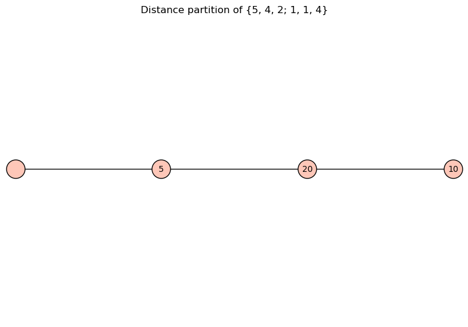

```python
syl.distancePartition()
```

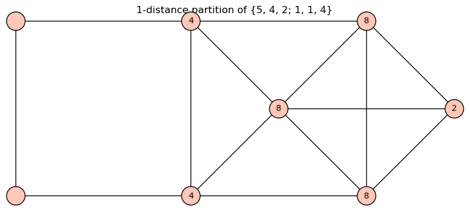

```python
syl.distancePartition(1)
```

## Parameter computation: parameters with variables

Let us define a *one-parametric family* of *intersection arrays*.

```python
r = var("r")
f = DRGParameters([2*r^2*(2*r+1), (2*r-1)*(2*r^2+r+1), 2*r^2], [1, 2*r^2, r*(4*r^2-1)])
f
```

```
Parameters of a distance-regular graph with intersection array {4*r^3 + 2*r^2, 4*r^3 + r - 1, 2*r^2; 1, 2*r^2, 4*r^3 - r}
```

```python
f1 = f.subs(r == 1)
f1
```

```
Parameters of a distance-regular graph with intersection array {6, 4, 2; 1, 2, 3}
```

The parameters of `f1` are known to uniquely determine the *Hamming scheme $H(3, 3)$*.

```python
f2 = f.subs(r == 2)
f2
```

```
Parameters of a distance-regular graph with intersection array {40, 33, 8; 1, 8, 30}
```

## Feasibility checking

A parameter set is called **feasible** if it passes all known *existence conditions*.

Let us verify that *$H(3, 3)$* is feasible.

```python
f1.check_feasible()
```

No error has occured, since all existence conditions are met.

Let us now check whether the second member of the family is feasible.

```python
f2.check_feasible()
```

```
---------------------------------------------------------------------------
InfeasibleError                           Traceback (most recent call last)
<ipython-input-15-83a4aafdb73c> in <module>()
----> 1 f2.check_feasible()

/home/janos/repos/git/sage-drg/jupyter/2019-07-04-fpsac/drg/drg.pyc in check_feasible(self, checked, skip, derived)
    682         for name, check in checks:
    683             if name not in skip:
--> 684                 check()
    685         if not derived:
    686             return

/home/janos/repos/git/sage-drg/jupyter/2019-07-04-fpsac/drg/drg.pyc in check_family(self)
    643                            in zip(self.b[:-1] + self.c[1:], b + c)], vars)
    644             if any(checkConditions(cond, sol) for sol in sols):
--> 645                 raise InfeasibleError(refs = ref)
    646
    647     def check_feasible(self, checked = None, skip = None, derived = True):

InfeasibleError: nonexistence by JurišićVidali12
```

In this case, nonexistence has been shown by *matching* the parameters against a list of **nonexistent families**.

## Triple intersection numbers

- In some cases, **triple intersection numbers** can be computed.
- Nonexistence of some *$Q$-polynomial* association schemes has been proven by obtaining a *contradiction* in *double counting* with triple intersection numbers.

```python
q225.check_quadruples()
```

```
---------------------------------------------------------------------------
InfeasibleError                           Traceback (most recent call last)
<ipython-input-16-40f750f5d8a3> in <module>()
----> 1 q225.check_quadruples()

/home/janos/repos/git/sage-drg/jupyter/2019-07-04-fpsac/drg/assoc_scheme.py in check_quadruples(self, solver)
    685                                         "d(w, y) = %d, d(w, z) = %d, "
    686                                         "d(x, y) = %d, d(x, z) = %d, "
--> 687                                         "d(y, z) = %d" % (sd + st))
    688                                 if len(r[st]) < l:
    689                                     zero[st] = {(sh, si, sj)

InfeasibleError: found forbidden quadruple wxyz with d(w, x) = 1, d(w, y) = 1, d(w, z) = 1, d(x, y) = 3, d(x, z) = 3, d(y, z) = 3
```

*Integer linear programming* has been used to find solutions to multiple systems of *linear Diophantine equations*, *eliminating* inconsistent solutions.